# Project 1_Hao Hu

# Inferring reasons why a huge reduction between people who vote for Democrat in 2012 and 2016 exist

As the American election ended a while ago, Joe Biden was inaugurated as the 46th president of the United States. United States election is one of the biggest event in every people in the United States. That makes people think a lot about what affect the voting result.

The line chart below shows the voting result in ANES data. From the chart, People who vote for Democrat party is much greater than people who vote for Republican party in 2012 and in 2016 People who vote for Democrat party is still greater than Republican party but it is not that too much. What causes that happened? A huge reduction in the number of voters who vote for Democrat might be caused by many reasons.

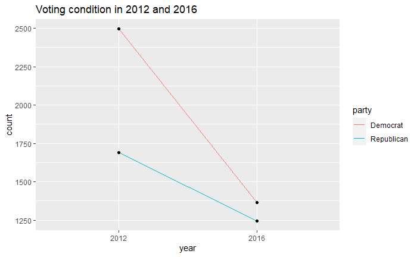

There are so many factors may affect the voting. Now, focusing on Religious beliefs. Does what voter believe might affect the voting result? According to our analysis of ANES data, religious beliefs affect the voting result indeed.

First up, as the bar chart below shows, people think religious beliefs is important in voting which is twice as much as who think is not important in both 2012 and 2016. From this chart, we can preliminary conclude that religious beliefs have some impact on voting.

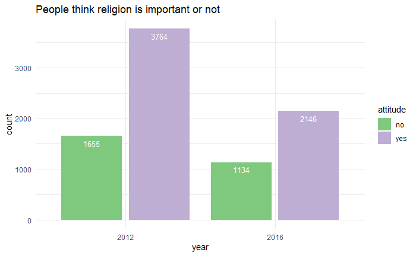

### Protestant has much proportion on Republican in 2016.

But how believes affect the religious. The pie charts show the distribution of voters in different religions voting condition. In 2012, it is obvious that Protestant has weighted approximately 50 percent of the total proportion on both Democrat and Republican and Jewish only weighted a tiny part of the total proportion on both Democrat and Republican. Unfortunately, it is hard for us to find out how beliefs affect the voting result in 2012.

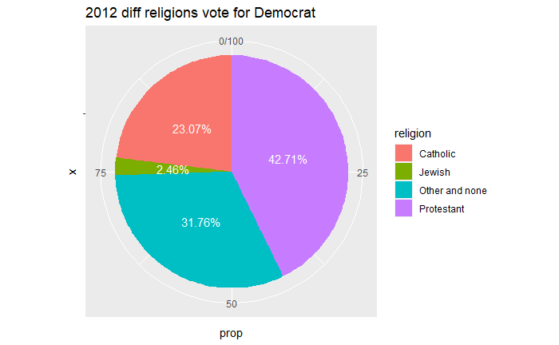

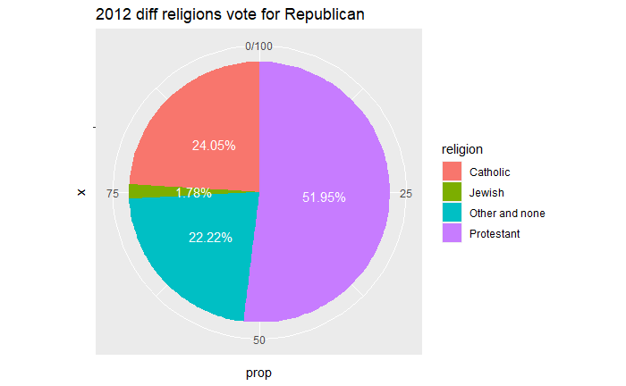

In 2016 pie chart, it is quite different from the pie chart in 2012 since the proportion of some religions change a lot. It seems that lots of Protestants voted for Republican in 2016 since the proportion of the Protestants decrease a lot comparing to 2012. That might explain why there exist a huge gap in the line chart above.

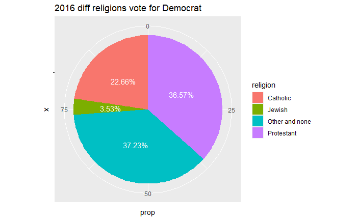

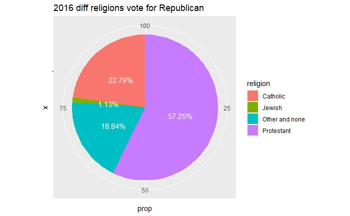